# Testing Simulation

2022-11-21

# Set constant

# Generate the baseline equilibrium

# Comparative statics

## Setting

$constant $constant$n_ths $constant$n_ths[[1]] $constant$n_ths[[1]][[1]] [1] 3

$constant$n_market [1] 1

$constant$n_zone [1] 1

$constant$n_x_a [1] 2

$constant$n_x_c [1] 2

$constant$method_s_w [1] “exact”

$constant$margin [1] 1e-10

$constant$quadrature_size [1] 21

$constant$tol [1] 1e-16

$constant$minimum_wage [1] FALSE

$constant$use_parallel [1] TRUE

$constant$use_rcpp [1] TRUE

$parameter $parameter$m_w [1] 0.5

$parameter$m_f [1] 0.5

$parameter$lambda_w [1] 0.5

$parameter$lambda_f [1] -0.5

$parameter$beta_w [1] 10 -1

$parameter$beta_f [1] 10 1

$parameter$gamma_w [1] 0.3 0.3

$parameter$gamma_f [1] 0.3 0.3

$shock $shock[[1]] $shock[[1]][[1]] $shock[[1]][[1]]$mu [,1] [1,] 0.9 [2,] 0.9 [3,] 0.9

$shock[[1]][[1]]$ea_w [,1] [1,] 0 [2,] 0 [3,] 0

$shock[[1]][[1]]$ea_f [,1] [1,] 0 [2,] 0 [3,] 0

$shock[[1]][[1]]$ec_w [,1] [1,] 0 [2,] 0 [3,] 0

$shock[[1]][[1]]$ec_f [,1] [1,] 0 [2,] 0 [3,] 0

$exogenous $exogenous[[1]] $exogenous[[1]][[1]] $exogenous[[1]][[1]]$x_a_w [,1] [,2] [1,] 1 0 [2,] 1 1 [3,] 1 0

$exogenous[[1]][[1]]$x_a_f [,1] [,2] [1,] 1 0 [2,] 1 1 [3,] 1 0

$exogenous[[1]][[1]]$x_c_w [,1] [,2] [1,] 1 0 [2,] 1 1 [3,] 1 0

$exogenous[[1]][[1]]$x_c_f [,1] [,2] [1,] 1 0 [2,] 1 1 [3,] 1 0

$exogenous[[1]][[1]]$w_0 [1] -10

$exogenous[[1]][[1]]$f_0 [1] 0

$exogenous[[1]][[1]]$size_w [1] 1

$exogenous[[1]][[1]]$size_f [1] 1

$exogenous[[1]][[1]]$owner [,1] [,2] [,3] [1,] 1 0 0 [2,] 0 1 0 [3,] 0 0 1

$endogenous $endogenous[[1]] $endogenous[[1]][[1]] $endogenous[[1]][[1]]$w [,1] [1,] 0.3 [2,] 0.1 [3,] 0.1

$endogenous[[1]][[1]]$f [,1] [1,] 0.6 [2,] 5.1 [3,] 5.1

$endogenous[[1]][[1]]$s_w [,1] [1,] 0.3333333 [2,] 0.3333333 [3,] 0.3333333

$endogenous[[1]][[1]]$s_f [,1] [1,] 0.3333333 [2,] 0.3333333 [3,] 0.3333333

$endogenous[[1]][[1]]$eta_w [,1] [1,] 0.01 [2,] 0.01

$endogenous[[1]][[1]]$eta_f [,1] [1,] 0.01 [2,] 0.01

## Check the foc at the baseline

| target | i | foc_w | foc_f | foc_s_f | w | f | m | s_w | s_f | meeting_probability_w | meeting_probability_f | c_w | c_f | profit_ths | surplus_w | surplus_f |
| --- | --- | --- | --- | --- | --- | --- | --- | --- | --- | --- | --- | --- | --- | --- | --- | --- |
| 0.5 | 0 | NA | NA | NA | NA | NA | NA | -0.7971467 | 0.0000397 | NA | NA | NA | NA | NA | 0.1256723 | 0.0008506 |
| 0.5 | 1 | NA | NA | 0 | 0.300000 | 0.600000 | 0.300000 | 0.8011849 | 0.6977927 | 0.7518059 | 1.077406 | 0.3 | 0.3 | -0.2093378 | 17.4699490 | 15.9939922 |
| 0.5 | 2 | 0 | 0 | 0 | 3.037479 | 10.272616 | 7.235137 | 0.6574214 | 0.0540756 | 0.2092875 | 3.870274 | 0.6 | 0.6 | 0.8804837 | 15.1030977 | 3.9171414 |
| 0.5 | 3 | 0 | 0 | 0 | -2.452043 | 3.702368 | 6.154411 | 0.3385403 | 0.2480919 | 0.4482795 | 1.806909 | 0.3 | 0.3 | 0.8140418 | 6.8146679 | 9.0731650 |

## Parameter

### m_w (Matching coefficient of worker)

#### table

| target | i | foc_w | foc_f | foc_s_f | w | f | m | s_w | s_f | meeting_probability_w | meeting_probability_f | c_w | c_f | profit_ths | surplus_w | surplus_f |
| --- | --- | --- | --- | --- | --- | --- | --- | --- | --- | --- | --- | --- | --- | --- | --- | --- |
| 0.25 | 0 | NA | NA | NA | NA | NA | NA | -1.1879439 | 0.0000001 | NA | NA | NA | NA | NA | 0.7691084 | 0.0000042 |
| 0.30 | 0 | NA | NA | NA | NA | NA | NA | -1.2040998 | 0.0000002 | NA | NA | NA | NA | NA | 0.6506551 | 0.0000063 |
| 0.35 | 0 | NA | NA | NA | NA | NA | NA | -1.2044742 | 0.0000002 | NA | NA | NA | NA | NA | 0.5357544 | 0.0000060 |
| 0.40 | 0 | NA | NA | NA | NA | NA | NA | -1.1843382 | 0.0000003 | NA | NA | NA | NA | NA | 0.4286847 | 0.0000098 |
| 0.45 | 0 | NA | NA | NA | NA | NA | NA | -0.7993045 | 0.0000413 | NA | NA | NA | NA | NA | 0.1423377 | 0.0008811 |
| 0.50 | 0 | NA | NA | NA | NA | NA | NA | -0.7971467 | 0.0000397 | NA | NA | NA | NA | NA | 0.1256723 | 0.0008506 |
| 0.55 | 0 | NA | NA | NA | NA | NA | NA | -0.7992990 | 0.0000386 | NA | NA | NA | NA | NA | 0.1092288 | 0.0008297 |
| 0.60 | 0 | NA | NA | NA | NA | NA | NA | -0.8018505 | 0.0000379 | NA | NA | NA | NA | NA | 0.0935470 | 0.0008158 |
| 0.65 | 0 | NA | NA | NA | NA | NA | NA | -0.4846722 | 0.0000162 | NA | NA | NA | NA | NA | 0.0707452 | 0.0003754 |
| 0.70 | 0 | NA | NA | NA | NA | NA | NA | -0.7684174 | 0.0000013 | NA | NA | NA | NA | NA | 0.1056989 | 0.0000360 |
| 0.75 | 0 | NA | NA | NA | NA | NA | NA | -0.6754513 | 0.0000015 | NA | NA | NA | NA | NA | 0.0832393 | 0.0000428 |
| 0.25 | 1 | NA | NA | 0e+00 | 0.300000 | 0.600000 | 0.300000 | 0.9998065 | 0.0044920 | 0.0156162 | 3.476418 | 0.3 | 0.3 | -0.0013476 | 21.4506662 | 0.4898059 |
| 0.30 | 1 | NA | NA | -1e-07 | 0.300000 | 0.600000 | 0.300000 | 0.9997589 | 0.0075077 | 0.0293155 | 3.904725 | 0.3 | 0.3 | -0.0022523 | 21.4497407 | 0.8893762 |
| 0.35 | 1 | NA | NA | 0e+00 | 0.300000 | 0.600000 | 0.300000 | 0.9996896 | 0.0123838 | 0.0518320 | 4.185463 | 0.3 | 0.3 | -0.0037151 | 21.4483922 | 1.5206033 |
| 0.40 | 1 | NA | NA | 0e+00 | 0.300000 | 0.600000 | 0.300000 | 0.9995886 | 0.0199976 | 0.0860656 | 4.303792 | 0.3 | 0.3 | -0.0059993 | 21.4464281 | 2.4424302 |
| 0.45 | 1 | NA | NA | 0e+00 | 0.300000 | 0.600000 | 0.300000 | 0.8013601 | 0.7078317 | 0.7442246 | 1.051415 | 0.3 | 0.3 | -0.2123495 | 17.4819701 | 15.8114456 |
| 0.50 | 1 | NA | NA | 0e+00 | 0.300000 | 0.600000 | 0.300000 | 0.8011849 | 0.6977927 | 0.7518059 | 1.077406 | 0.3 | 0.3 | -0.2093378 | 17.4699490 | 15.9939922 |
| 0.55 | 1 | NA | NA | 0e+00 | 0.300000 | 0.600000 | 0.300000 | 0.7989337 | 0.6937351 | 0.7634484 | 1.100490 | 0.3 | 0.3 | -0.2081205 | 17.4109191 | 16.2505796 |
| 0.60 | 1 | NA | NA | 0e+00 | 0.300000 | 0.600000 | 0.300000 | 0.7952540 | 0.6934847 | 0.7774228 | 1.121038 | 0.3 | 0.3 | -0.2080454 | 17.3184582 | 16.5485970 |
| 0.65 | 1 | NA | NA | 0e+00 | 0.300000 | 0.600000 | 0.300000 | 0.9700370 | 0.4178972 | 0.6631577 | 1.586892 | 0.3 | 0.3 | -0.1253692 | 20.8702444 | 14.7880661 |
| 0.70 | 1 | NA | NA | 0e+00 | 0.300000 | 0.600000 | 0.300000 | 0.9990649 | 0.0953344 | 0.4446490 | 4.664100 | 0.3 | 0.3 | -0.0286003 | 21.4362386 | 11.2296830 |
| 0.75 | 1 | NA | NA | 0e+00 | 0.300000 | 0.600000 | 0.300000 | 0.9990029 | 0.1103665 | 0.5187425 | 4.700180 | 0.3 | 0.3 | -0.0331100 | 21.4350312 | 12.9490209 |
| 0.25 | 2 | 0 | 0e+00 | 0e+00 | -15.267372 | -8.924353 | 6.343020 | 0.5976137 | 0.4512603 | 0.4955219 | 1.098084 | 0.6 | 0.6 | 1.4299283 | 2.8761238 | 16.6843252 |
| 0.30 | 2 | 0 | 0e+00 | 0e+00 | -14.767445 | -8.020695 | 6.746750 | 0.6084110 | 0.4462237 | 0.5115986 | 1.146507 | 0.6 | 0.6 | 1.6455170 | 3.1921264 | 16.7748055 |
| 0.35 | 2 | 0 | -8e-07 | 0e+00 | -14.189071 | -7.012393 | 7.176678 | 0.6132855 | 0.4355195 | 0.5243212 | 1.203898 | 0.6 | 0.6 | 1.8534756 | 3.5345947 | 16.6887541 |
| 0.40 | 2 | 0 | 0e+00 | 0e+00 | -13.517698 | -5.885803 | 7.631895 | 0.6116849 | 0.4141619 | 0.5303281 | 1.280485 | 0.6 | 0.6 | 2.0326050 | 3.8988883 | 16.3358185 |
| 0.45 | 2 | 0 | 0e+00 | 0e+00 | 2.599296 | 9.225680 | 6.626384 | 0.6109748 | 0.0720593 | 0.2118225 | 2.939558 | 0.6 | 0.6 | 0.7366881 | 13.8413462 | 4.0647212 |
| 0.50 | 2 | 0 | 0e+00 | 0e+00 | 3.037479 | 10.272616 | 7.235137 | 0.6574214 | 0.0540756 | 0.2092875 | 3.870274 | 0.6 | 0.6 | 0.8804837 | 15.1030977 | 3.9171414 |
| 0.55 | 2 | 0 | 0e+00 | 0e+00 | 3.482323 | 11.490288 | 8.007965 | 0.7008794 | 0.0394193 | 0.2100446 | 5.328472 | 0.6 | 0.6 | 1.0669187 | 16.3367615 | 3.8083481 |
| 0.60 | 2 | 0 | 0e+00 | 0e+00 | 3.939094 | 12.945286 | 9.006191 | 0.7420958 | 0.0273530 | 0.2133264 | 7.799005 | 0.6 | 0.6 | 1.3143611 | 17.5615685 | 3.7133738 |
| 0.65 | 2 | 0 | 0e+00 | 0e+00 | -5.653856 | 3.332630 | 8.986486 | 0.2264654 | 0.3346973 | 0.6135794 | 1.833237 | 0.6 | 0.6 | 0.9645219 | 3.2906574 | 13.5054100 |
| 0.70 | 2 | 0 | 0e+00 | 0e+00 | -10.849267 | 2.052249 | 12.901516 | 0.4638533 | 0.1119994 | 0.4666671 | 4.166693 | 0.6 | 0.6 | 2.5956490 | 4.0262087 | 11.8910081 |
| 0.75 | 2 | 0 | 0e+00 | 0e+00 | -10.536624 | 4.624159 | 15.160783 | 0.4156309 | 0.0618972 | 0.4489111 | 7.252521 | 0.6 | 0.6 | 2.6796316 | 3.7148099 | 10.8164373 |
| 0.25 | 3 | 0 | 0e+00 | 0e+00 | -17.479415 | -11.392752 | 6.086663 | 0.5905237 | 0.5442475 | 0.5702822 | 1.047836 | 0.3 | 0.3 | 1.7854723 | 2.7191621 | 19.2549446 |
| 0.30 | 3 | 0 | 2e-07 | 0e+00 | -17.034454 | -10.546648 | 6.487806 | 0.5959299 | 0.5462684 | 0.5894225 | 1.078998 | 0.3 | 0.3 | 2.0096141 | 2.9750017 | 19.3981138 |
| 0.35 | 3 | 0 | -6e-07 | 0e+00 | -16.556351 | -9.652788 | 6.903563 | 0.5914992 | 0.5520965 | 0.6117194 | 1.107994 | 0.3 | 0.3 | 2.2237483 | 3.2080510 | 19.5721369 |
| 0.40 | 3 | 0 | 0e+00 | 0e+00 | -16.077506 | -8.759556 | 7.317950 | 0.5730647 | 0.5658401 | 0.6395268 | 1.130225 | 0.3 | 0.3 | 2.4022582 | 3.3636330 | 19.8591459 |
| 0.45 | 3 | 0 | 0e+00 | 0e+00 | -1.816560 | 3.987986 | 5.804546 | 0.3869696 | 0.2200677 | 0.3914249 | 1.778657 | 0.3 | 0.3 | 0.7677507 | 8.0160327 | 7.9044680 |
| 0.50 | 3 | 0 | 0e+00 | 0e+00 | -2.452043 | 3.702368 | 6.154411 | 0.3385403 | 0.2480919 | 0.4482795 | 1.806909 | 0.3 | 0.3 | 0.8140418 | 6.8146679 | 9.0731650 |
| 0.55 | 3 | 0 | 0e+00 | 0e+00 | -2.990563 | 3.562251 | 6.552814 | 0.2994858 | 0.2668070 | 0.4966280 | 1.861376 | 0.3 | 0.3 | 0.8499582 | 5.8743414 | 10.0490896 |
| 0.60 | 3 | 0 | 0e+00 | 0e+00 | -3.507830 | 3.512229 | 7.020059 | 0.2645007 | 0.2791244 | 0.5402088 | 1.935369 | 0.3 | 0.3 | 0.8764622 | 5.0532101 | 10.9091906 |
| 0.65 | 3 | 0 | 0e+00 | 0e+00 | -6.361947 | 2.330098 | 8.692045 | 0.2881698 | 0.2473893 | 0.5519832 | 2.231233 | 0.3 | 0.3 | 1.2606628 | 4.5303832 | 11.9327269 |
| 0.70 | 3 | 0 | 0e+00 | 0e+00 | -15.968427 | -6.601235 | 9.367192 | 0.3054993 | 0.7926650 | 0.8394009 | 1.058960 | 0.3 | 0.3 | 2.0873580 | 1.8078621 | 23.6882074 |
| 0.75 | 3 | 0 | 0e+00 | -1e-07 | -16.172749 | -6.452101 | 9.720649 | 0.2608176 | 0.8277347 | 0.8584506 | 1.037108 | 0.3 | 0.3 | 1.8609536 | 1.4827875 | 24.0234454 |

#### foc_w

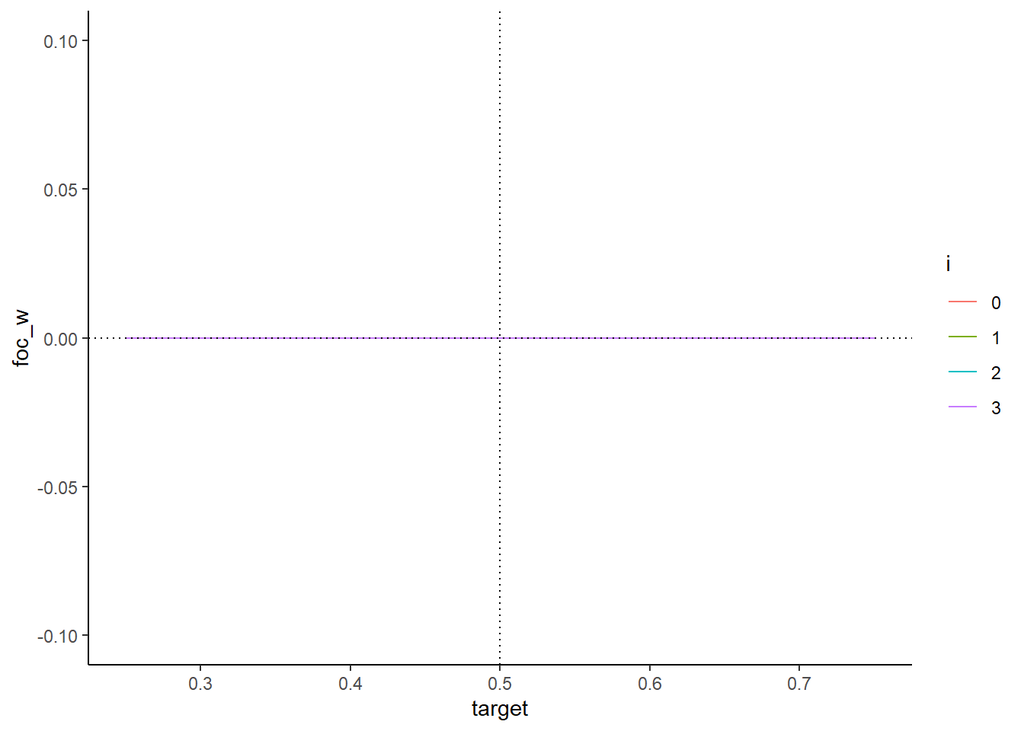

#### foc_f

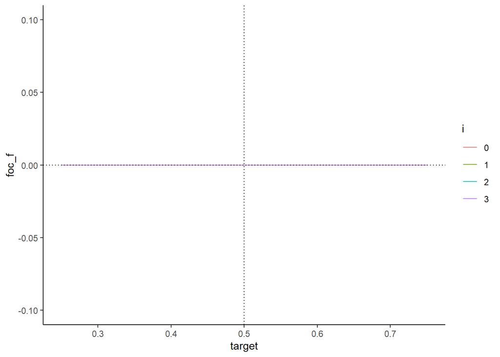

#### foc_s_f

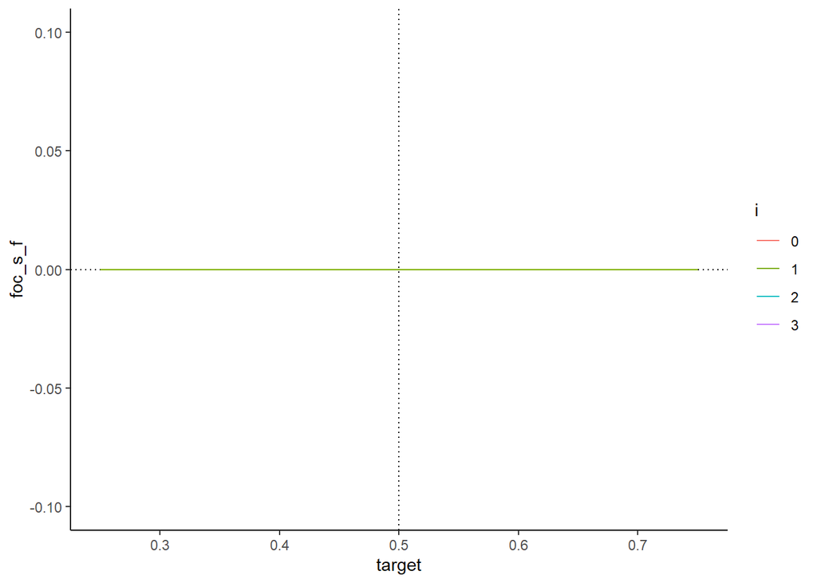

#### w

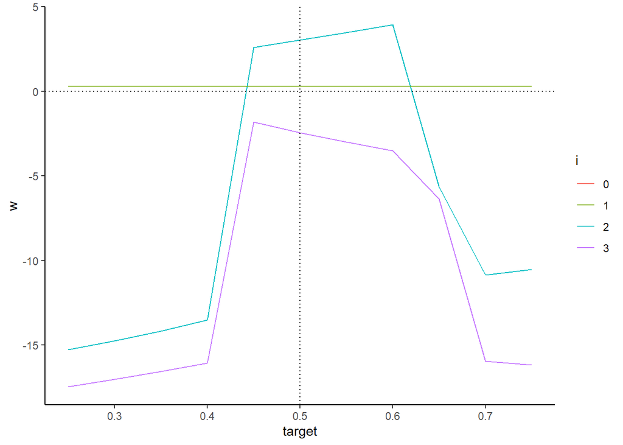

#### f

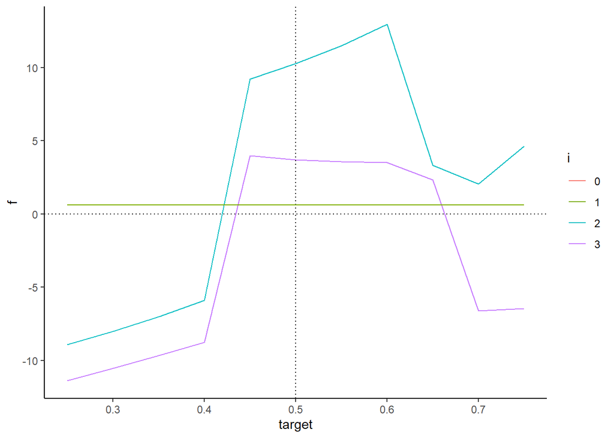

#### m

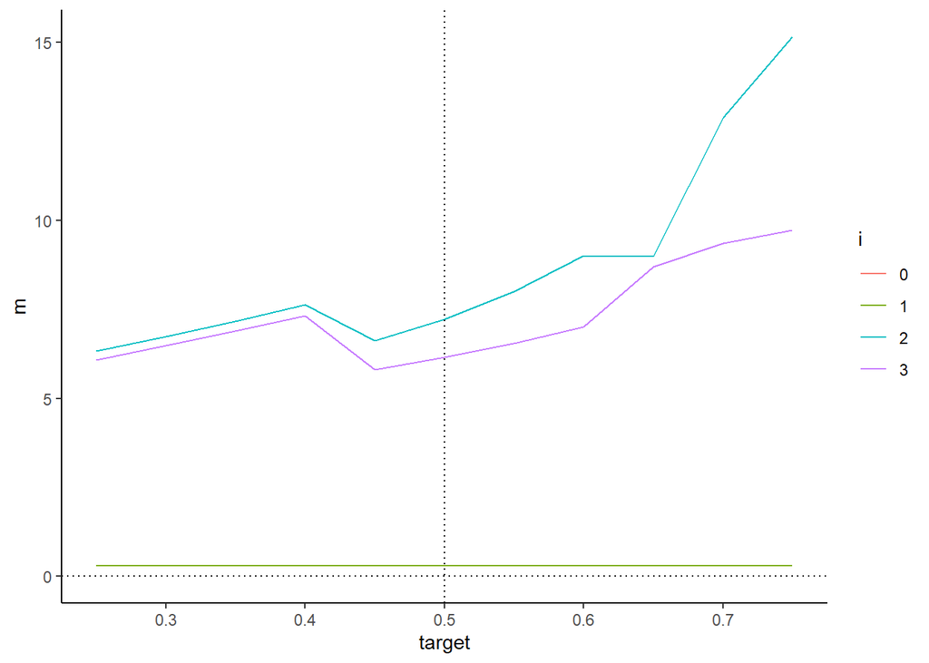

#### s_w

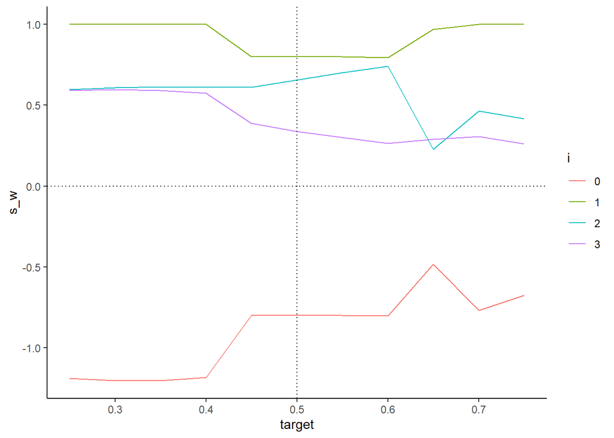

#### s_f

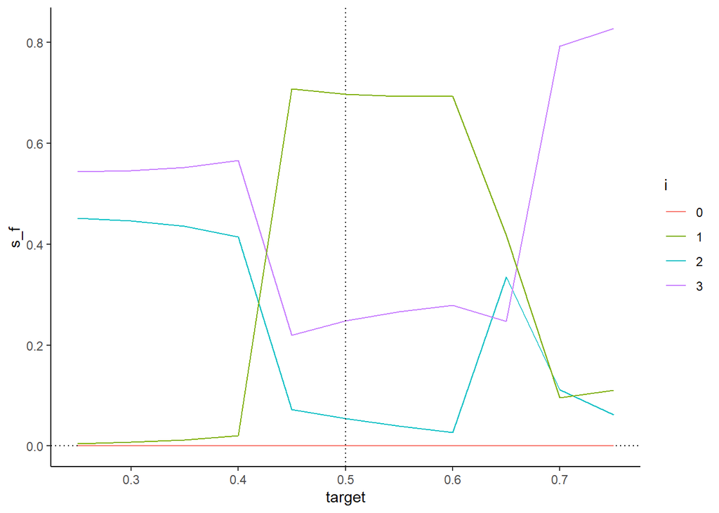

#### meeting_probability_w

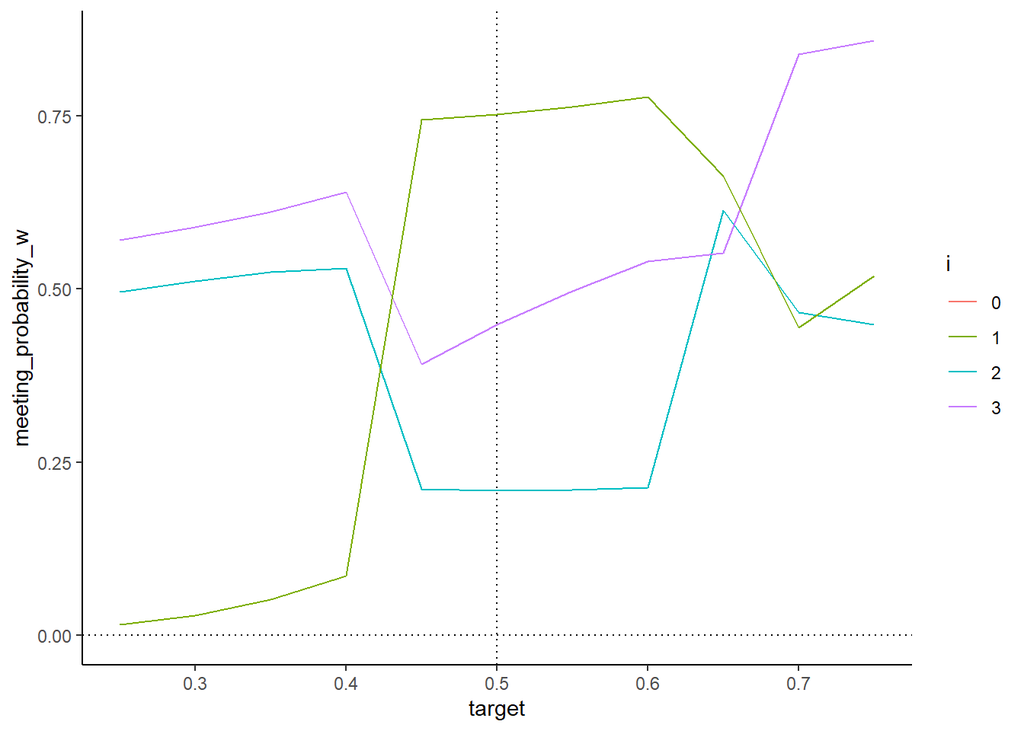

#### meeting_probability_f

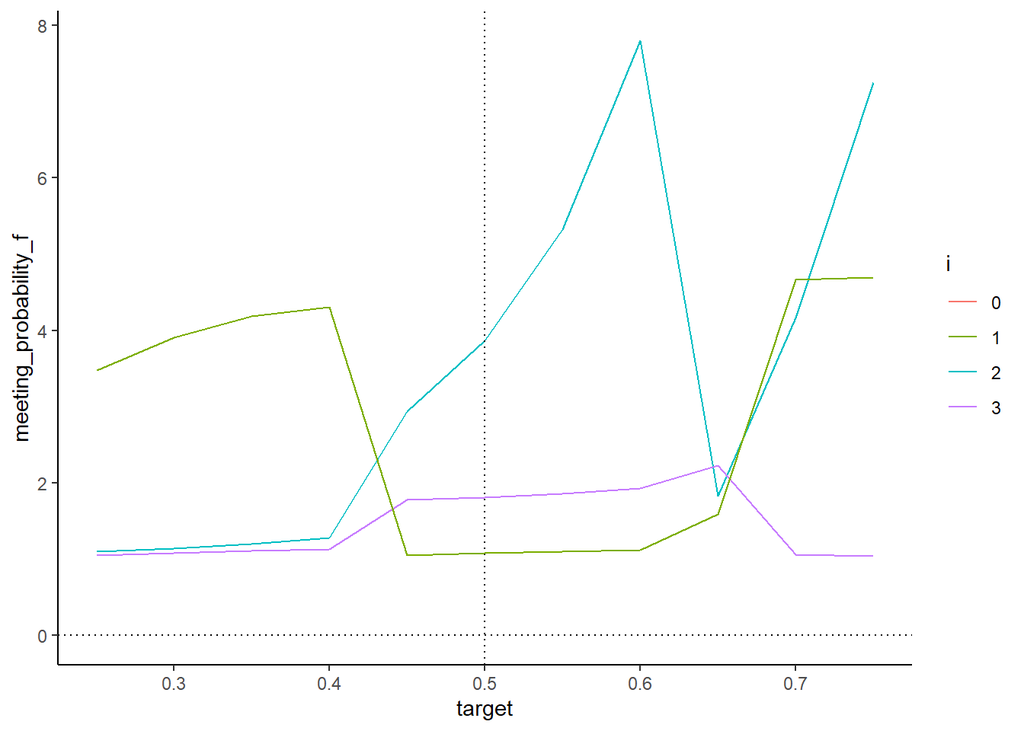

#### c_w

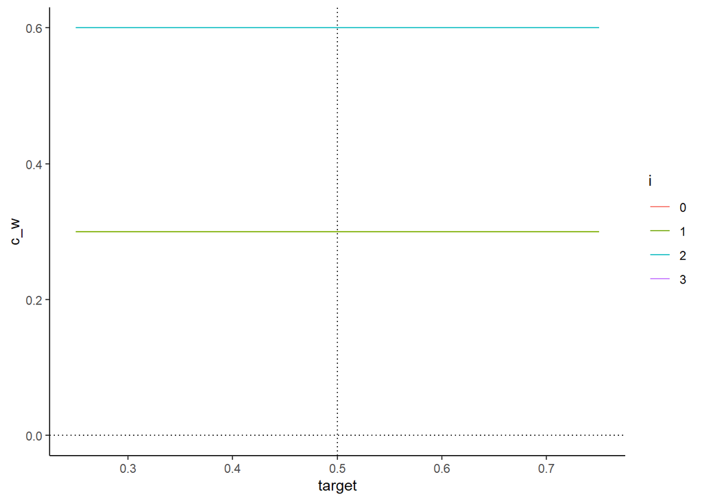

#### c_f

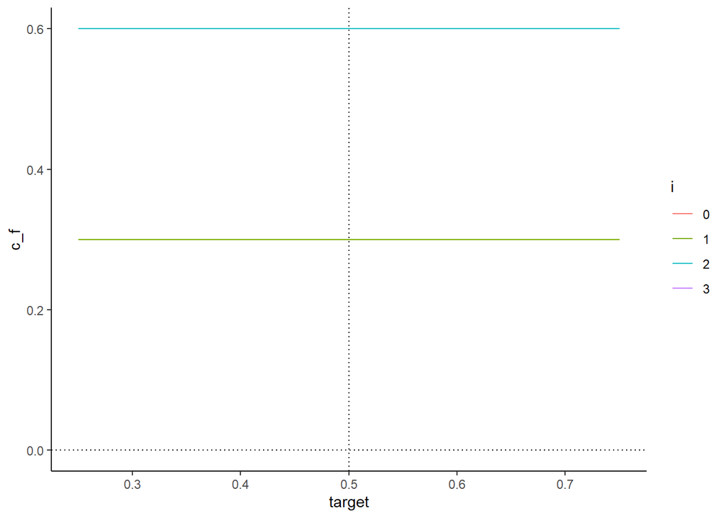

#### profit_ths

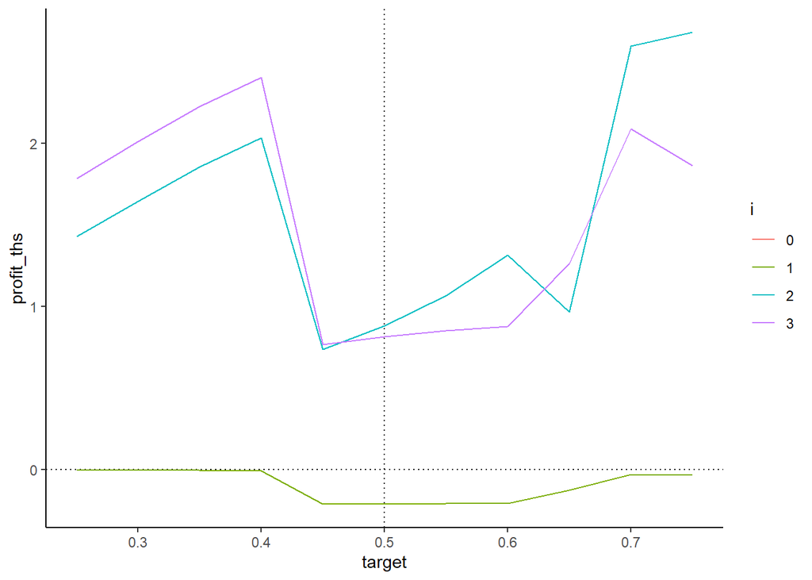

#### surplus_w

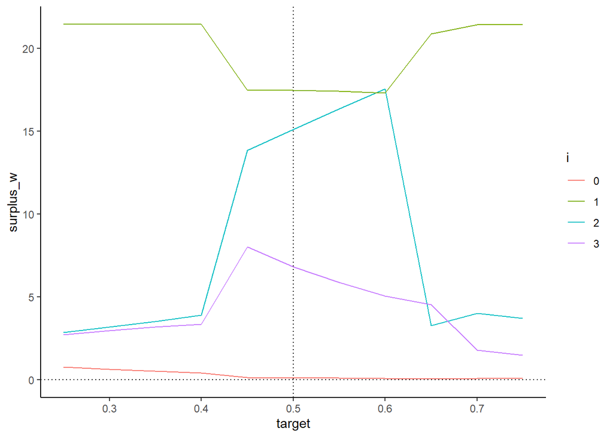

#### surplus_f

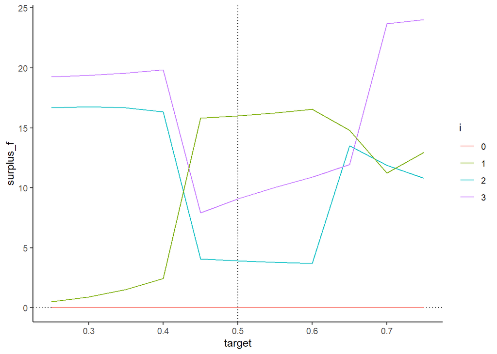

### beta_w (Worker’s utility)

#### table

| target | i | foc_w | foc_f | foc_s_f | w | f | m | s_w | s_f | meeting_probability_w | meeting_probability_f | c_w | c_f | profit_ths | surplus_w | surplus_f |
| --- | --- | --- | --- | --- | --- | --- | --- | --- | --- | --- | --- | --- | --- | --- | --- | --- |
| -1.5 | 0 | NA | NA | NA | NA | NA | NA | -0.7373649 | 0.0000428 | NA | NA | NA | NA | NA | 0.1219354 | 0.0009110 |
| -1.4 | 0 | NA | NA | NA | NA | NA | NA | -0.7405961 | 0.0000423 | NA | NA | NA | NA | NA | 0.1224649 | 0.0008999 |
| -1.3 | 0 | NA | NA | NA | NA | NA | NA | -1.0814098 | 0.0000007 | NA | NA | NA | NA | NA | 0.2684899 | 0.0000199 |
| -1.2 | 0 | NA | NA | NA | NA | NA | NA | -1.0823008 | 0.0000007 | NA | NA | NA | NA | NA | 0.2681111 | 0.0000200 |
| -1.1 | 0 | NA | NA | NA | NA | NA | NA | -0.5769846 | 0.0000292 | NA | NA | NA | NA | NA | 0.1272440 | 0.0006430 |
| -1.0 | 0 | NA | NA | NA | NA | NA | NA | -0.7971467 | 0.0000397 | NA | NA | NA | NA | NA | 0.1256723 | 0.0008506 |
| -0.9 | 0 | NA | NA | NA | NA | NA | NA | -0.7940879 | 0.0000395 | NA | NA | NA | NA | NA | 0.1255258 | 0.0008468 |
| -0.8 | 0 | NA | NA | NA | NA | NA | NA | -0.5890994 | 0.0000275 | NA | NA | NA | NA | NA | 0.1277413 | 0.0006095 |
| -0.7 | 0 | NA | NA | NA | NA | NA | NA | -0.7878218 | 0.0000391 | NA | NA | NA | NA | NA | 0.1252599 | 0.0008389 |
| -0.6 | 0 | NA | NA | NA | NA | NA | NA | -1.0865693 | 0.0000006 | NA | NA | NA | NA | NA | 0.2629945 | 0.0000188 |
| -0.5 | 0 | NA | NA | NA | NA | NA | NA | -1.0239290 | 0.0000549 | NA | NA | NA | NA | NA | 0.1106066 | 0.0011409 |
| -1.5 | 1 | NA | NA | 0e+00 | 0.3000000 | 0.600000 | 0.300000 | 0.8202008 | 0.7337886 | 0.7709532 | 1.0506475 | 0.3 | 0.3 | -0.2201366 | 17.8480784 | 16.3237768 |
| -1.4 | 1 | NA | NA | -1e-07 | 0.3000000 | 0.600000 | 0.300000 | 0.8188482 | 0.7266669 | 0.7672028 | 1.0557834 | 0.3 | 0.3 | -0.2180001 | 17.8219559 | 16.2593339 |
| -1.3 | 1 | NA | NA | 0e+00 | 0.3000000 | 0.600000 | 0.300000 | 0.9993761 | 0.0449901 | 0.1908979 | 4.2431066 | 0.3 | 0.3 | -0.0134970 | 21.4422934 | 5.1078650 |
| -1.2 | 1 | NA | NA | 0e+00 | 0.3000000 | 0.600000 | 0.300000 | 0.9993639 | 0.0442492 | 0.1893195 | 4.2784825 | 0.3 | 0.3 | -0.0132748 | 21.4420550 | 5.0719189 |
| -1.1 | 1 | NA | NA | 0e+00 | 0.3000000 | 0.600000 | 0.300000 | 0.8906626 | 0.5682511 | 0.6784419 | 1.1939121 | 0.3 | 0.3 | -0.1704753 | 19.3059310 | 14.7118869 |
| -1.0 | 1 | NA | NA | 0e+00 | 0.3000000 | 0.600000 | 0.300000 | 0.8011849 | 0.6977927 | 0.7518059 | 1.0774057 | 0.3 | 0.3 | -0.2093378 | 17.4699490 | 15.9939922 |
| -0.9 | 1 | NA | NA | 0e+00 | 0.3000000 | 0.600000 | 0.300000 | 0.7983457 | 0.6955028 | 0.7505713 | 1.0791780 | 0.3 | 0.3 | -0.2086508 | 17.4119518 | 15.9726612 |
| -0.8 | 1 | NA | NA | 0e+00 | 0.3000000 | 0.600000 | 0.300000 | 0.8885977 | 0.5463685 | 0.6652507 | 1.2175861 | 0.3 | 0.3 | -0.1639105 | 19.2655552 | 14.4780866 |
| -0.7 | 1 | NA | NA | 0e+00 | 0.3000000 | 0.600000 | 0.300000 | 0.7924854 | 0.6906358 | 0.7479405 | 1.0829739 | 0.3 | 0.3 | -0.2071907 | 17.2922344 | 15.9271810 |
| -0.6 | 1 | NA | NA | 0e+00 | 0.3000000 | 0.600000 | 0.300000 | 0.9992692 | 0.0406711 | 0.1815037 | 4.4627201 | 0.3 | 0.3 | -0.0122013 | 21.4402136 | 4.8931402 |
| -0.5 | 1 | NA | NA | 0e+00 | 0.3000000 | 0.600000 | 0.300000 | 0.7166091 | 0.8663894 | 0.8377204 | 0.9669097 | 0.3 | 0.3 | -0.2599168 | 15.6699714 | 17.4591591 |
| -1.5 | 2 | 0 | 0 | 0e+00 | -0.3846202 | 6.569924 | 6.954544 | 0.2721313 | 0.1953735 | 0.3978097 | 2.0361497 | 0.6 | 0.6 | 0.5706963 | 5.2463656 | 7.8965980 |
| -1.4 | 2 | 0 | 0 | 0e+00 | -0.5243528 | 6.428002 | 6.952354 | 0.2774673 | 0.2028502 | 0.4053500 | 1.9982730 | 0.6 | 0.6 | 0.5927480 | 5.3623767 | 8.0733585 |
| -1.3 | 2 | 0 | 0 | 0e+00 | -11.6857210 | -3.110063 | 8.575658 | 0.5858785 | 0.3018099 | 0.4944350 | 1.6382335 | 0.6 | 0.6 | 2.1292934 | 4.3850645 | 14.1707107 |
| -1.2 | 2 | 0 | 0 | 0e+00 | -11.8596099 | -3.241314 | 8.618296 | 0.5877243 | 0.3101146 | 0.5011914 | 1.6161489 | 0.6 | 0.6 | 2.1758196 | 4.4124653 | 14.4029246 |
| -1.1 | 2 | 0 | 0 | 0e+00 | -1.7134242 | 5.468498 | 7.181922 | 0.3073461 | 0.2184151 | 0.4206141 | 1.9257557 | 0.6 | 0.6 | 0.7198230 | 5.7122274 | 8.7187619 |
| -1.0 | 2 | 0 | 0 | 0e+00 | 3.0374788 | 10.272616 | 7.235137 | 0.6574214 | 0.0540756 | 0.2092875 | 3.8702745 | 0.6 | 0.6 | 0.8804837 | 15.1030977 | 3.9171414 |
| -0.9 | 2 | 0 | 0 | 0e+00 | 2.8417390 | 10.099031 | 7.257292 | 0.6584258 | 0.0571088 | 0.2150770 | 3.7660932 | 0.6 | 0.6 | 0.9084889 | 15.1270038 | 4.0393599 |
| -0.8 | 2 | 0 | 0 | 0e+00 | -2.1405407 | 5.058946 | 7.199487 | 0.3265211 | 0.2407225 | 0.4415713 | 1.8343583 | 0.6 | 0.6 | 0.8070959 | 6.1105375 | 9.2481400 |
| -0.7 | 2 | 0 | 0 | 0e+00 | 2.4502872 | 9.754178 | 7.303891 | 0.6605052 | 0.0636174 | 0.2270024 | 3.5682449 | 0.6 | 0.6 | 0.9669856 | 15.1763201 | 4.2926124 |
| -0.6 | 2 | 0 | 0 | 0e+00 | -12.8678162 | -3.977942 | 8.889874 | 0.5969771 | 0.3643682 | 0.5432662 | 1.4909817 | 0.6 | 0.6 | 2.4699305 | 4.5863168 | 15.8370554 |
| -0.5 | 2 | 0 | 0 | 0e+00 | 2.8033415 | 10.158815 | 7.355474 | 0.6635011 | 0.0697369 | 0.2376697 | 3.4080914 | 0.6 | 0.6 | 1.0234563 | 15.7365253 | 4.3545050 |
| -1.5 | 3 | 0 | 0 | 0e+00 | 0.8379272 | 7.615295 | 6.777368 | 0.6450327 | 0.0707951 | 0.2394661 | 3.3825251 | 0.3 | 0.3 | 0.9792782 | 14.7094690 | 4.5103597 |
| -1.4 | 3 | 0 | 0 | 0e+00 | 0.8251680 | 7.601092 | 6.775924 | 0.6442807 | 0.0704407 | 0.2388659 | 3.3910234 | 0.3 | 0.3 | 0.9754912 | 14.6848877 | 4.5048464 |
| -1.3 | 3 | 0 | 0 | 0e+00 | -15.6600264 | -7.426318 | 8.233708 | 0.4961552 | 0.6531993 | 0.7273867 | 1.1135754 | 0.3 | 0.3 | 2.6672891 | 3.0984927 | 21.4088069 |
| -1.2 | 3 | 0 | 0 | 0e+00 | -15.6228660 | -7.441193 | 8.181673 | 0.4952127 | 0.6456355 | 0.7231630 | 1.1200794 | 0.3 | 0.3 | 2.6288902 | 3.1143032 | 21.3120944 |
| -1.1 | 3 | 0 | 0 | 0e+00 | -2.9201569 | 3.539526 | 6.459683 | 0.3789759 | 0.2133046 | 0.4156642 | 1.9486882 | 0.3 | 0.3 | 0.9063234 | 7.3881226 | 8.6063170 |
| -1.0 | 3 | 0 | 0 | 0e+00 | -2.4520425 | 3.702368 | 6.154411 | 0.3385403 | 0.2480919 | 0.4482795 | 1.8069086 | 0.3 | 0.3 | 0.8140418 | 6.8146679 | 9.0731650 |
| -0.9 | 3 | 0 | 0 | 0e+00 | -2.4570256 | 3.701505 | 6.158531 | 0.3373164 | 0.2473489 | 0.4476077 | 1.8096205 | 0.3 | 0.3 | 0.8103479 | 6.7889548 | 9.0626395 |
| -0.8 | 3 | 0 | 0 | 0e+00 | -3.0456202 | 3.427674 | 6.473294 | 0.3739806 | 0.2128815 | 0.4152517 | 1.9506239 | 0.3 | 0.3 | 0.8948240 | 7.2445911 | 8.6458724 |
| -0.7 | 3 | 0 | 0 | 0e+00 | -2.4670869 | 3.700410 | 6.167496 | 0.3348312 | 0.2457077 | 0.4461202 | 1.8156540 | 0.3 | 0.3 | 0.8027447 | 6.7367633 | 9.0389523 |
| -0.6 | 3 | 0 | 0 | 0e+00 | -15.3296996 | -7.448931 | 7.880768 | 0.4903229 | 0.5949601 | 0.6942029 | 1.1668058 | 0.3 | 0.3 | 2.4018813 | 3.2460252 | 20.5774829 |
| -0.5 | 3 | 0 | 0 | 0e+00 | 1.6650480 | 8.424862 | 6.759814 | 0.6438187 | 0.0638188 | 0.2273614 | 3.5626104 | 0.3 | 0.3 | 0.9264388 | 15.2120547 | 4.1454767 |

#### foc_w

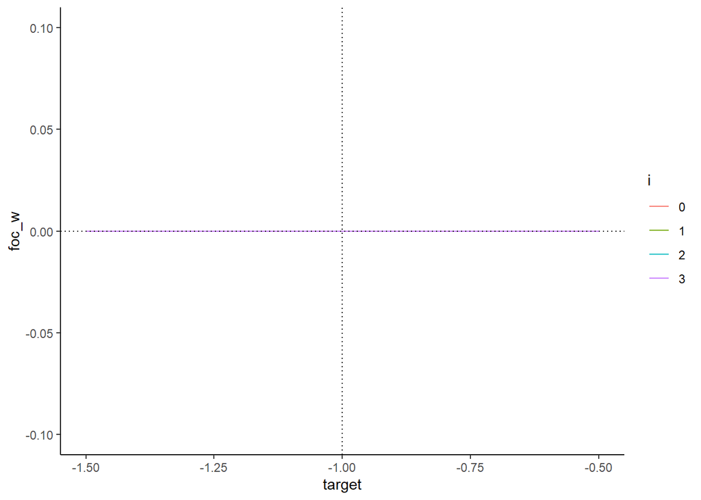

#### foc_f

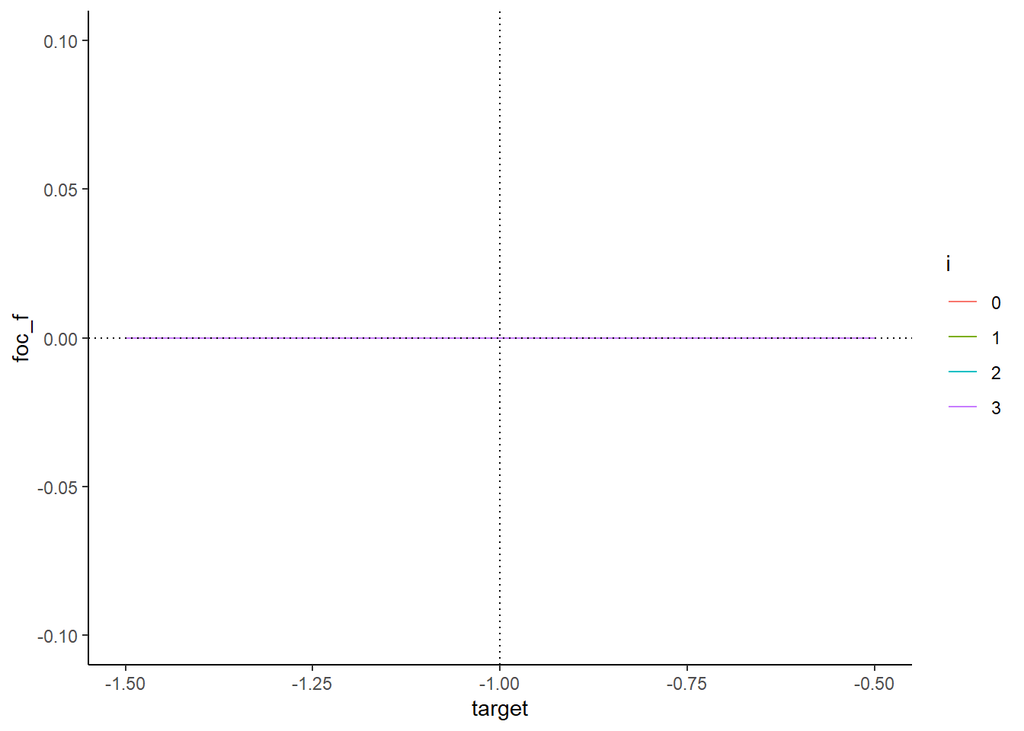

#### foc_s_f

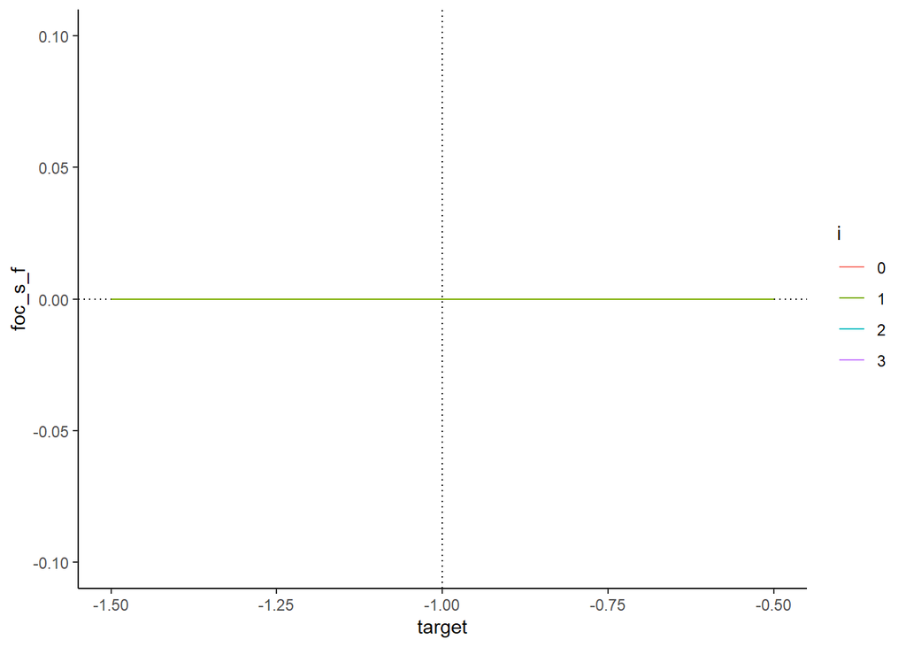

#### w

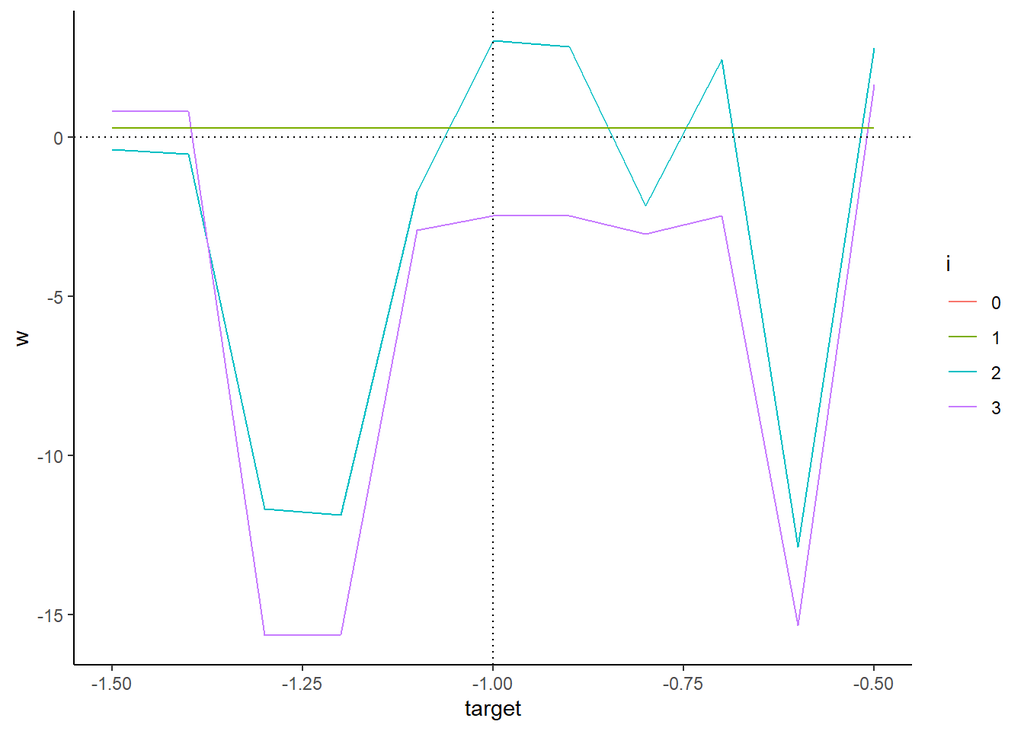

#### f

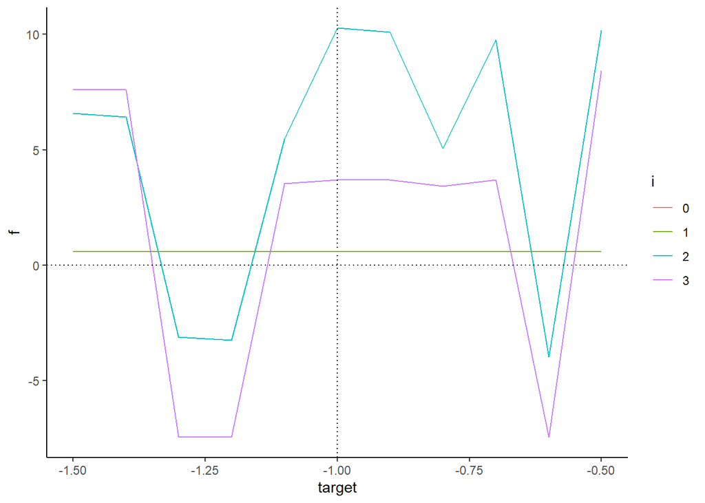

#### m

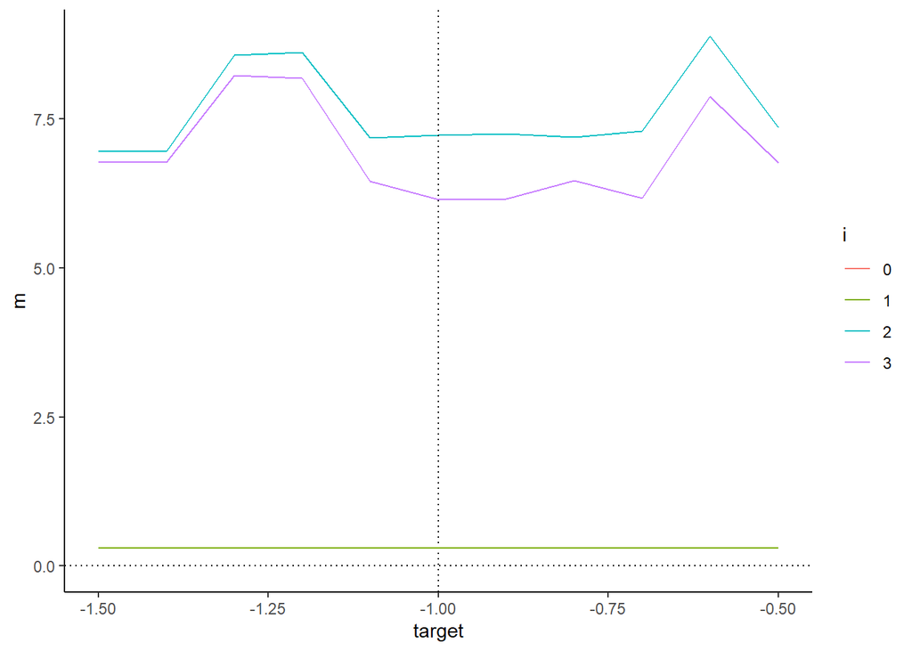

#### s_w

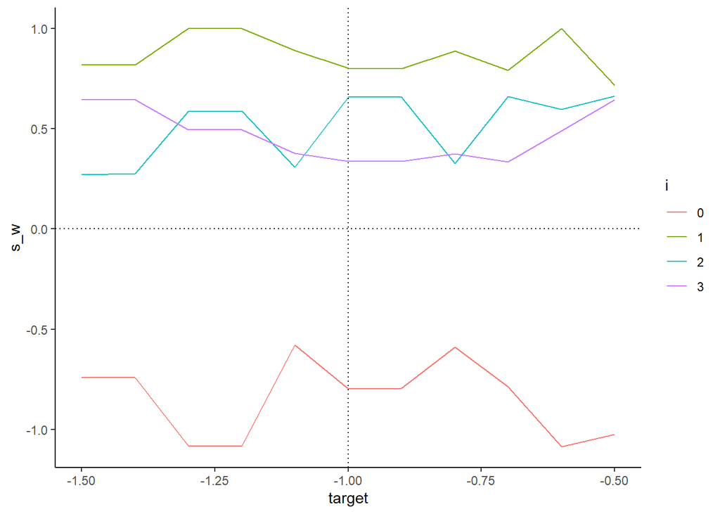

#### s_f

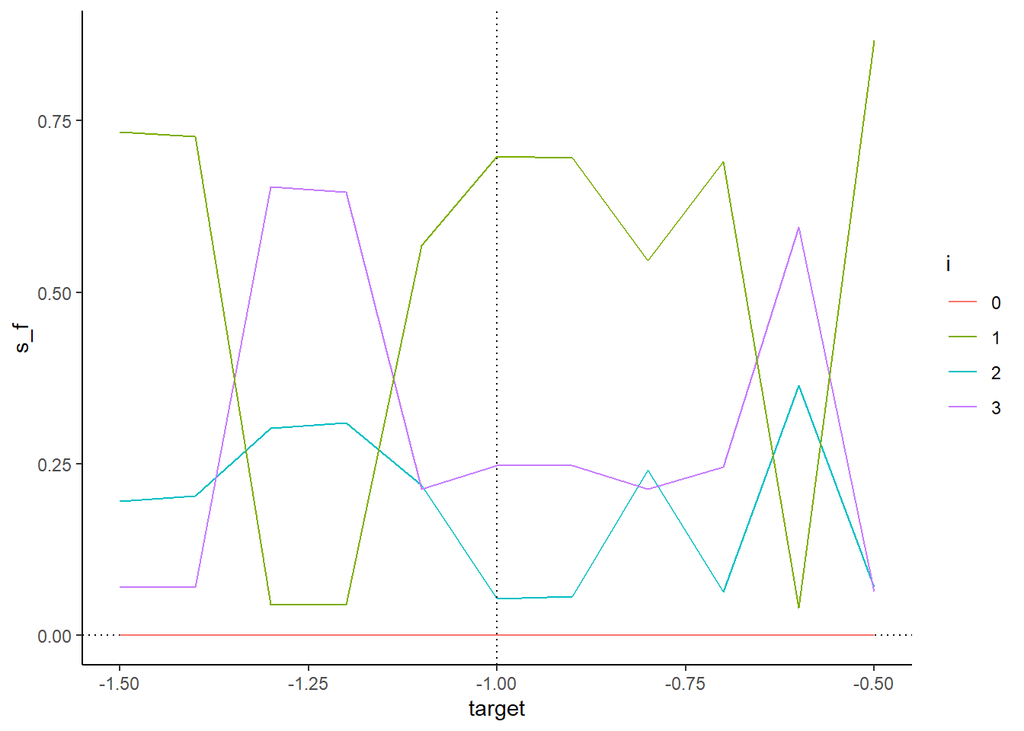

#### meeting_probability_w

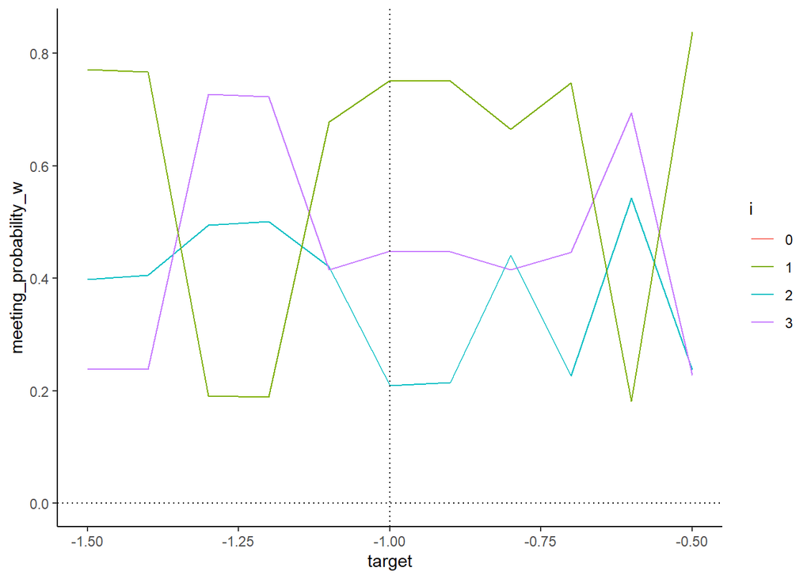

#### meeting_probability_f

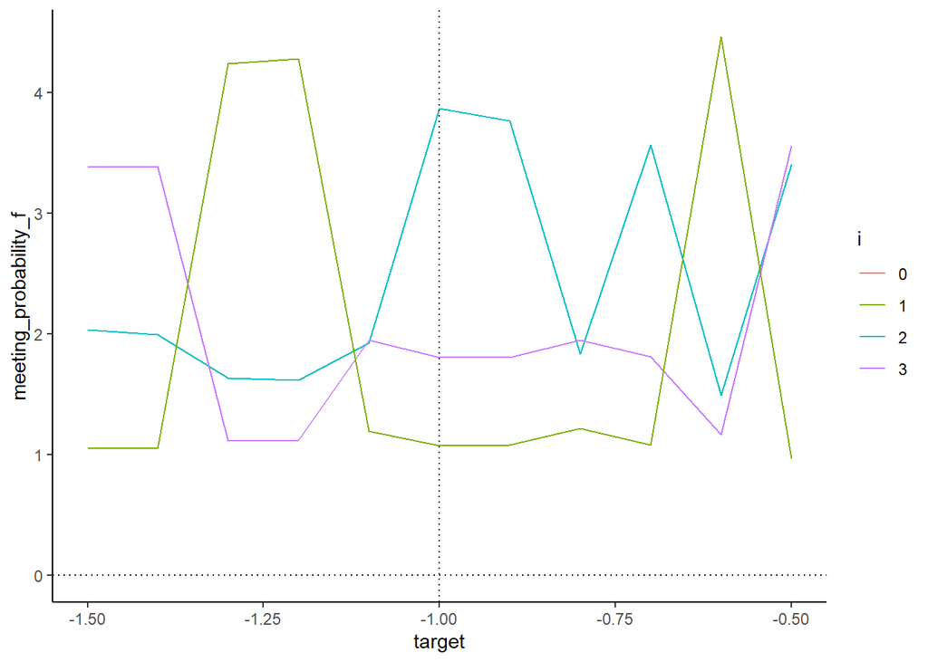

#### c_w

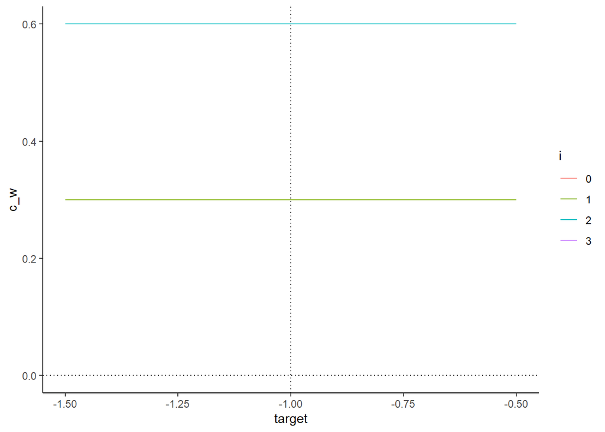

#### c_f

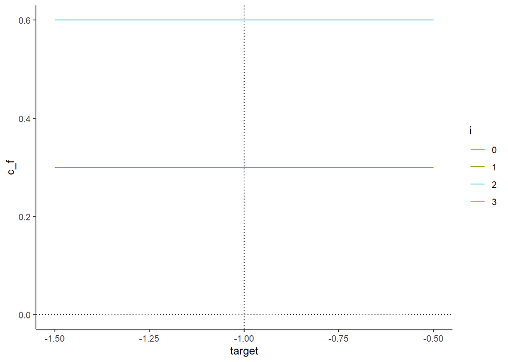

#### profit_ths

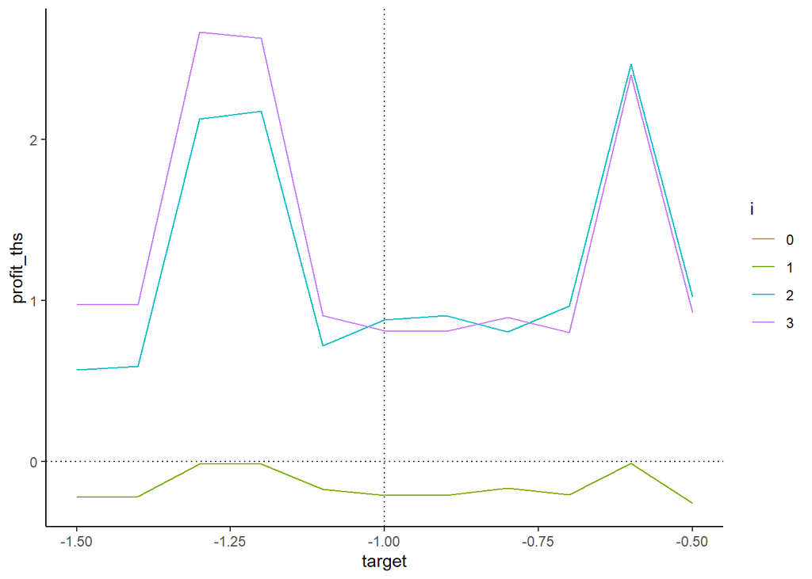

#### surplus_w

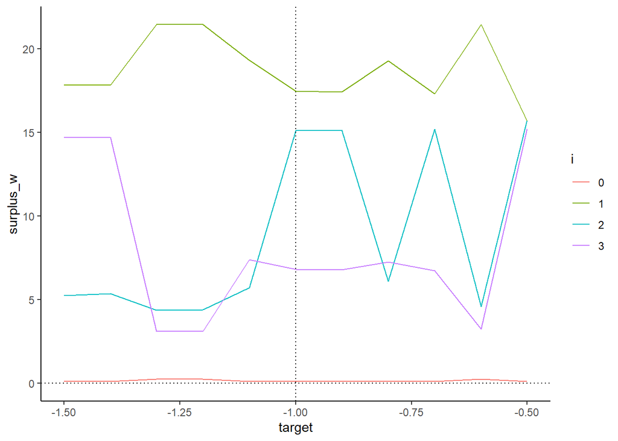

#### surplus_f

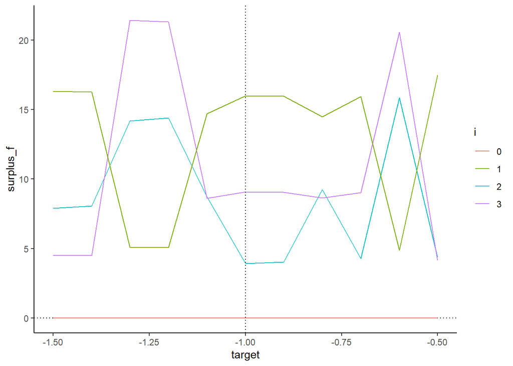

### beta_f (Client firm’s utility)

#### table

| target | i | foc_w | foc_f | foc_s_f | w | f | m | s_w | s_f | meeting_probability_w | meeting_probability_f | c_w | c_f | profit_ths | surplus_w | surplus_f |
| --- | --- | --- | --- | --- | --- | --- | --- | --- | --- | --- | --- | --- | --- | --- | --- | --- |
| 0.5 | 0 | NA | NA | NA | NA | NA | NA | -0.7373649 | 0.0000428 | NA | NA | NA | NA | NA | 0.1219354 | 0.0009110 |
| 0.6 | 0 | NA | NA | NA | NA | NA | NA | -1.0493468 | 0.0000572 | NA | NA | NA | NA | NA | 0.1089955 | 0.0011832 |
| 0.7 | 0 | NA | NA | NA | NA | NA | NA | -1.0467352 | 0.0000570 | NA | NA | NA | NA | NA | 0.1090994 | 0.0011807 |
| 0.8 | 0 | NA | NA | NA | NA | NA | NA | -0.5729001 | 0.0000297 | NA | NA | NA | NA | NA | 0.1270732 | 0.0006540 |
| 0.9 | 0 | NA | NA | NA | NA | NA | NA | -0.8001547 | 0.0000399 | NA | NA | NA | NA | NA | 0.1258271 | 0.0008542 |
| 1.0 | 0 | NA | NA | NA | NA | NA | NA | -0.7971467 | 0.0000397 | NA | NA | NA | NA | NA | 0.1256723 | 0.0008506 |
| 1.1 | 0 | NA | NA | NA | NA | NA | NA | -0.7940879 | 0.0000395 | NA | NA | NA | NA | NA | 0.1255258 | 0.0008468 |
| 1.2 | 0 | NA | NA | NA | NA | NA | NA | -1.0854017 | 0.0000006 | NA | NA | NA | NA | NA | 0.2653743 | 0.0000191 |
| 1.3 | 0 | NA | NA | NA | NA | NA | NA | -0.7643697 | 0.0000377 | NA | NA | NA | NA | NA | 0.1260351 | 0.0008120 |
| 1.4 | 0 | NA | NA | NA | NA | NA | NA | -1.0865693 | 0.0000006 | NA | NA | NA | NA | NA | 0.2629945 | 0.0000188 |
| 1.5 | 0 | NA | NA | NA | NA | NA | NA | -1.0239290 | 0.0000549 | NA | NA | NA | NA | NA | 0.1106066 | 0.0011409 |
| 0.5 | 1 | NA | NA | 0e+00 | 0.3000000 | 0.600000 | 0.300000 | 0.8202008 | 0.7337886 | 0.7709532 | 1.0506475 | 0.3 | 0.3 | -0.2201366 | 17.8480784 | 16.3237768 |
| 0.6 | 1 | NA | NA | 0e+00 | 0.3000000 | 0.600000 | 0.300000 | 0.7448730 | 0.8900598 | 0.8490868 | 0.9539660 | 0.3 | 0.3 | -0.2670179 | 16.2525429 | 17.6502774 |
| 0.7 | 1 | NA | NA | -1e-07 | 0.3000000 | 0.600000 | 0.300000 | 0.7419819 | 0.8879274 | 0.8480691 | 0.9551109 | 0.3 | 0.3 | -0.2663782 | 16.1929602 | 17.6331900 |
| 0.8 | 1 | NA | NA | 0e+00 | 0.3000000 | 0.600000 | 0.300000 | 0.8912530 | 0.5754001 | 0.6826962 | 1.1864721 | 0.3 | 0.3 | -0.1726200 | 19.3174433 | 14.7870704 |
| 0.9 | 1 | NA | NA | 0e+00 | 0.3000000 | 0.600000 | 0.300000 | 0.8039635 | 0.6999911 | 0.7529892 | 1.0757126 | 0.3 | 0.3 | -0.2099973 | 17.5267043 | 16.0144295 |
| 1.0 | 1 | NA | NA | 0e+00 | 0.3000000 | 0.600000 | 0.300000 | 0.8011849 | 0.6977927 | 0.7518059 | 1.0774057 | 0.3 | 0.3 | -0.2093378 | 17.4699490 | 15.9939922 |
| 1.1 | 1 | NA | NA | 0e+00 | 0.3000000 | 0.600000 | 0.300000 | 0.7983457 | 0.6955028 | 0.7505713 | 1.0791780 | 0.3 | 0.3 | -0.2086508 | 17.4119518 | 15.9726612 |
| 1.2 | 1 | NA | NA | 0e+00 | 0.3000000 | 0.600000 | 0.300000 | 0.9993060 | 0.0416703 | 0.1837197 | 4.4088896 | 0.3 | 0.3 | -0.0125011 | 21.4409297 | 4.9439649 |
| 1.3 | 1 | NA | NA | 0e+00 | 0.3000000 | 0.600000 | 0.300000 | 0.8074913 | 0.6745007 | 0.7391519 | 1.0958505 | 0.3 | 0.3 | -0.2023502 | 17.6010104 | 15.7749781 |
| 1.4 | 1 | NA | NA | 0e+00 | 0.3000000 | 0.600000 | 0.300000 | 0.9992692 | 0.0406711 | 0.1815037 | 4.4627201 | 0.3 | 0.3 | -0.0122013 | 21.4402136 | 4.8931402 |
| 1.5 | 1 | NA | NA | 0e+00 | 0.3000000 | 0.600000 | 0.300000 | 0.7166091 | 0.8663894 | 0.8377204 | 0.9669097 | 0.3 | 0.3 | -0.2599168 | 15.6699714 | 17.4591591 |
| 0.5 | 2 | 0 | 0 | 0e+00 | -1.3846202 | 5.569924 | 6.954544 | 0.2721313 | 0.1953735 | 0.3978097 | 2.0361497 | 0.6 | 0.6 | 0.5706963 | 5.2463656 | 7.8965980 |
| 0.6 | 2 | 0 | 0 | 0e+00 | 3.7523217 | 10.906672 | 7.154351 | 0.6553343 | 0.0427655 | 0.1861183 | 4.3520696 | 0.6 | 0.6 | 0.7737731 | 15.5262362 | 3.3039370 |
| 0.7 | 2 | 0 | 0 | 0e+00 | 3.7579305 | 10.931814 | 7.173883 | 0.6561625 | 0.0452236 | 0.1913926 | 4.2321392 | 0.6 | 0.6 | 0.7984445 | 15.5478312 | 3.4096376 |
| 0.8 | 2 | 0 | 0 | 0e+00 | -1.9697984 | 5.210734 | 7.180532 | 0.3012808 | 0.2109219 | 0.4133361 | 1.9596645 | 0.6 | 0.6 | 0.6929221 | 5.5867412 | 8.5379659 |
| 0.9 | 2 | 0 | 0 | 0e+00 | 3.0332342 | 10.246949 | 7.213715 | 0.6564402 | 0.0511835 | 0.2036140 | 3.9781152 | 0.6 | 0.6 | 0.8532817 | 15.0796907 | 3.7978405 |
| 1.0 | 2 | 0 | 0 | 0e+00 | 3.0374788 | 10.272616 | 7.235137 | 0.6574214 | 0.0540756 | 0.2092875 | 3.8702745 | 0.6 | 0.6 | 0.8804837 | 15.1030977 | 3.9171414 |
| 1.1 | 2 | 0 | 0 | 0e+00 | 3.0417390 | 10.299031 | 7.257292 | 0.6584258 | 0.0571088 | 0.2150770 | 3.7660932 | 0.6 | 0.6 | 0.9084889 | 15.1270038 | 4.0393599 |
| 1.2 | 2 | 0 | 0 | 0e+00 | -12.1402211 | -3.343600 | 8.796621 | 0.5943571 | 0.3452683 | 0.5288358 | 1.5316662 | 0.6 | 0.6 | 2.3691790 | 4.5263221 | 15.3494066 |
| 1.3 | 2 | 0 | 0 | 0e+00 | -0.9026669 | 6.082677 | 6.985344 | 0.3175708 | 0.2580312 | 0.4571709 | 1.7717663 | 0.6 | 0.6 | 0.7722321 | 6.2400358 | 9.3176477 |
| 1.4 | 2 | 0 | 0 | 0e+00 | -12.0678162 | -3.177942 | 8.889874 | 0.5969771 | 0.3643682 | 0.5432662 | 1.4909817 | 0.6 | 0.6 | 2.4699305 | 4.5863168 | 15.8370554 |
| 1.5 | 2 | 0 | 0 | 0e+00 | 3.8033415 | 11.158815 | 7.355474 | 0.6635011 | 0.0697369 | 0.2376697 | 3.4080914 | 0.6 | 0.6 | 1.0234563 | 15.7365253 | 4.3545050 |
| 0.5 | 3 | 0 | 0 | 0e+00 | 0.8379272 | 7.615295 | 6.777368 | 0.6450327 | 0.0707951 | 0.2394661 | 3.3825251 | 0.3 | 0.3 | 0.9792782 | 14.7094690 | 4.5103597 |
| 0.6 | 3 | 0 | 0 | 0e+00 | 1.5803269 | 8.354530 | 6.774203 | 0.6491395 | 0.0671175 | 0.2331635 | 3.4739574 | 0.3 | 0.3 | 0.9597717 | 15.2772520 | 4.2441632 |
| 0.7 | 3 | 0 | 0 | 0e+00 | 1.5890798 | 8.361922 | 6.772842 | 0.6485908 | 0.0667920 | 0.2325973 | 3.4824142 | 0.3 | 0.3 | 0.9564583 | 15.2705676 | 4.2343992 |
| 0.8 | 3 | 0 | 0 | 0e+00 | -2.8818029 | 3.572203 | 6.454006 | 0.3803663 | 0.2136483 | 0.4159989 | 1.9471204 | 0.3 | 0.3 | 0.9096661 | 7.4298206 | 8.5983137 |
| 0.9 | 3 | 0 | 0 | 0e+00 | -2.4470966 | 3.703430 | 6.150527 | 0.3397510 | 0.2487855 | 0.4489056 | 1.8043883 | 0.3 | 0.3 | 0.8176641 | 6.8401074 | 9.0828549 |
| 1.0 | 3 | 0 | 0 | 0e+00 | -2.4520425 | 3.702368 | 6.154411 | 0.3385403 | 0.2480919 | 0.4482795 | 1.8069086 | 0.3 | 0.3 | 0.8140418 | 6.8146679 | 9.0731650 |
| 1.1 | 3 | 0 | 0 | 0e+00 | -2.4570255 | 3.701505 | 6.158531 | 0.3373164 | 0.2473489 | 0.4476077 | 1.8096205 | 0.3 | 0.3 | 0.8103479 | 6.7889548 | 9.0626395 |
| 1.2 | 3 | 0 | 0 | 0e+00 | -15.4446532 | -7.466026 | 7.978627 | 0.4917387 | 0.6130607 | 0.7046837 | 1.1494518 | 0.3 | 0.3 | 2.4768813 | 3.1928614 | 20.8579627 |
| 1.3 | 3 | 0 | 0 | 0e+00 | 0.7446362 | 7.508631 | 6.763995 | 0.6393076 | 0.0674304 | 0.2337063 | 3.4658891 | 0.3 | 0.3 | 0.9455575 | 14.5252632 | 4.4495615 |
| 1.4 | 3 | 0 | 0 | 0e+00 | -15.3296996 | -7.448931 | 7.880768 | 0.4903229 | 0.5949601 | 0.6942029 | 1.1668058 | 0.3 | 0.3 | 2.4018813 | 3.2460252 | 20.5774829 |
| 1.5 | 3 | 0 | 0 | 0e+00 | 1.6650481 | 8.424862 | 6.759814 | 0.6438188 | 0.0638188 | 0.2273614 | 3.5626104 | 0.3 | 0.3 | 0.9264388 | 15.2120548 | 4.1454767 |